# Reproducible Research: Peer Assessment 1

Ramon Schildknecht

15 April 2017

[Link to GitHub repository] (https://github.com/ramon-schildknecht/RepData_PeerAssessment1)

## Introduction

It is now possible to collect a large amount of data about personal movement using activity monitoring devices such as a Fitbit, Nike Fuelband, or Jawbone Up. These type of devices are part of the “quantified self” movement - a group of enthusiasts who take measurements about themselves regularly to improve their health, to find patterns in their behavior, or because they are tech geeks. But these data remain under-utilized both because the raw data are hard to obtain and there is a lack of statistical methods and software for processing and interpreting the data.

This assignment makes use of data from a personal activity monitoring device. This device collects data at 5 minute intervals through out the day. The data consists of two months of data from an anonymous individual collected during the months of October and November, 2012 and include the number of steps taken in 5 minute intervals each day.

The following elements are part and outcome of this document: - Code for reading in the dataset and/or processing the data - Histogram of the total number of steps taken each day - Mean and median number of steps taken each day - Time series plot of the average number of steps taken - The 5-minute interval that, on average, contains the maximum number of steps - Code to describe and show a strategy for imputing missing data - Histogram of the total number of steps taken each day after missing values are imputed - Panel plot comparing the average number of steps taken per 5-minute interval across weekdays and weekends - All of the R code needed to reproduce the results (numbers, plots, etc.) in the report

## Load packages and set global options

Global options echo = TRUE means that everybody can read the codes and results = ‘hold’ that the results will be displayed below the code.

```r
library(knitr)
library(dplyr)
```

```r
library(ggplot2)
library(lubridate)
source("multiplot function.R")
opts_chunk$set(echo = TRUE, results = 'hold')
```

## Loading and preprocessing the data

[This is the source of the data.] (https://d396qusza40orc.cloudfront.net/repdata%2Fdata%2Factivity.zip)

The data is already contained in the [GitHub repository] (http://github.com/rdpeng/RepData_PeerAssessment1) created for this assignment.

The variables included in the dataset are:

- steps: Number of steps taking in a 5-minute interval (missing values are coded as NA)
- date: The date on which the measurement was taken in YYYY-MM-DD format
- interval: Identifier for the 5-minute interval in which measurement was taken

### Load the data

```r
unzip("activity.zip")
d <- read.csv("activity.csv")
```

### Explore the data

Get dimensions, variable metadata and first observations. Get statistical summary. Get unique values for date which represents the number of days.

```r
str(d)
summary(d)
length(unique(d$date))
```

```
## 'data.frame':    17568 obs. of  3 variables:
##  $ steps   : int  NA NA NA NA NA NA NA NA NA NA ...
##  $ date    : Factor w/ 61 levels "2012-10-01","2012-10-02",..: 1 1 1 1 1 1 1 1 1 1 ...
##  $ interval: int  0 5 10 15 20 25 30 35 40 45 ...
##      steps                date          interval
##  Min.   :  0.00   2012-10-01:  288   Min.   :   0.0
##  1st Qu.:  0.00   2012-10-02:  288   1st Qu.: 588.8
##  Median :  0.00   2012-10-03:  288   Median :1177.5
##  Mean   : 37.38   2012-10-04:  288   Mean   :1177.5
##  3rd Qu.: 12.00   2012-10-05:  288   3rd Qu.:1766.2
##  Max.   :806.00   2012-10-06:  288   Max.   :2355.0
##  NA's   :2304     (Other)   :15840
## [1] 61
```

### Transform the data into suitable analysis format

Transform date to date type and interval to factor type.

```r
d$date <- ymd(d$date)
d$interval <- as.factor(d$interval)
```

## What is mean total number of steps taken per day?

Hint: For this part of the assignment, we can ignore the missing values in the dataset.

### Calculate the total number of steps taken per day

```r
d.steps.per.day <- aggregate(steps ~date, d, sum)
```

### Make a histogram of the total number of steps taken each day

Create histogram using ggplot2.

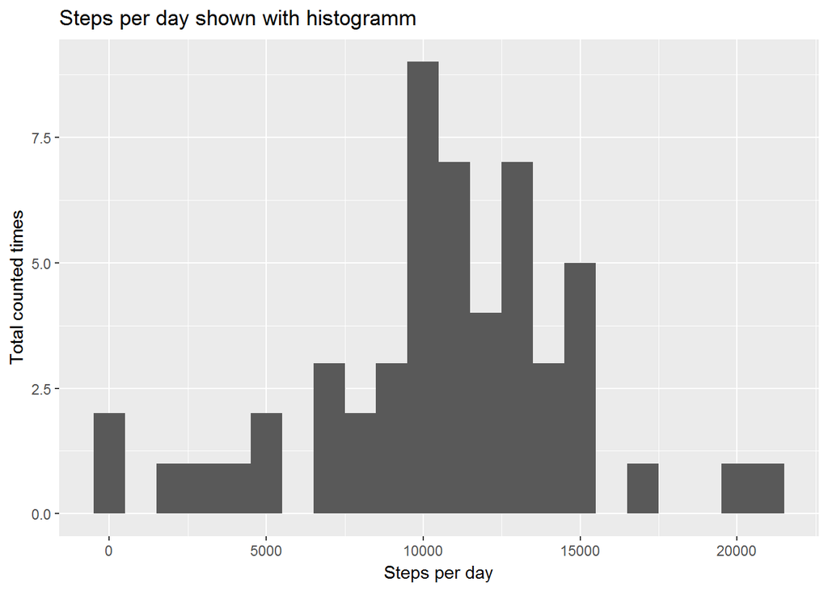

```r
g <- ggplot(d.steps.per.day, aes (x=steps))
g + geom_histogram(binwidth = 1000) + labs(x = "Steps per day", y = "Total counted times", title = "Steps per day shown with histogramm")
```

### Calculate and report the mean and median of the total number of steps taken per day

```r
mean.steps <- mean(d.steps.per.day$steps)
median.steps <- median(d.steps.per.day$steps)
```

Mean = 10766.19 steps Median = 10765.00 steps

## What is the average daily activity pattern?

### Make a time series plot

Create mean interval steps variable and set it to according interval. Transform interval to numeric type for better plot production. Create plot.

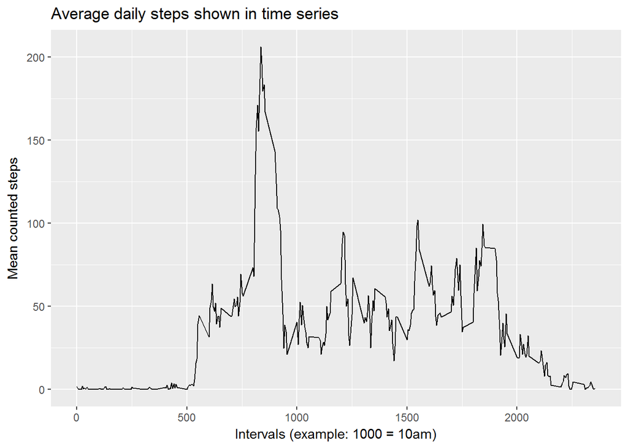

```r
d.intervall.steps <- aggregate(d$steps, by = list(interval = d$interval), FUN = mean, na.rm=TRUE)
colnames(d.intervall.steps) <- c("interval", "mean.steps")
d.intervall.steps$interval <- as.integer(levels(d.intervall.steps$interval)[d.intervall.steps$interval])
g <- ggplot(d.intervall.steps, aes(x = interval, y = mean.steps))
g + geom_line() + labs(x = "Intervals (example: 1000 = 10am)", y = "Mean counted steps", title = "Average daily steps shown in time series")
```

### Which 5-minute interval, on average across all the days in the dataset, contains the maximum number of steps?

```r
d.max.intervall <- d.intervall.steps %>% select(interval, mean.steps) %>% arrange(desc(mean.steps)) %>%  select(interval, mean.steps)
d.max.intervall[1,1]
```

```
## [1] 835
```

## Imputing missing values

### Calculate and report the total number of missing values in the dataset (i.e. the total number of rows with NAs)

```r
table(is.na(d$steps))
length(d$steps)
percentage.of.missing.values <- (table(is.na(d$steps))[2] / length(d$steps)) * 100
```

```
##
## FALSE  TRUE
## 15264  2304
## [1] 17568
```

About 13% of all step values are NAs.

### Devise a strategy for filling in all of the missing values in the dataset. The strategy does not need to be sophisticated. For example, you could use the mean/median for that day, or the mean for that 5-minute interval, etc.

We saw earlier that the mean and median for the steps variable are very close. Therefore we will use the steps mean per interval and replace the NAs in the suitable intervals.

```r
d.imputed <- d
for (i in 1:nrow(d.imputed)) {
          if (is.na(d.imputed$steps[i])) {
            d.intervall.value <- d.imputed$interval[i]
            d.steps.value <- d.intervall.steps[
                        d.intervall.steps$interval == d.intervall.value,]
            d.imputed$steps[i] <- d.steps.value$mean.steps
          }
}
```

### Create a new dataset that is equal to the original dataset but with the missing data filled in.

```r
d.clean <- d.imputed
```

### Make a histogram of the total number of steps taken each day and Calculate and report the mean and median total number of steps taken per day. Do these values differ from the estimates from the first part of the assignment? What is the impact of imputing missing data on the estimates of the total daily number of steps?

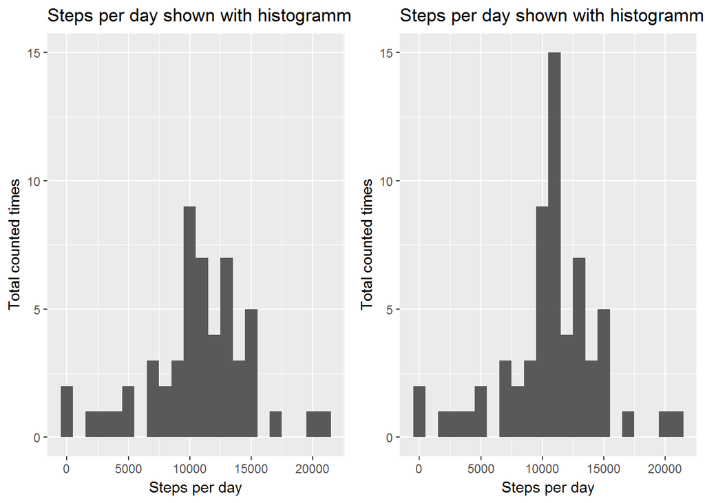

```r
d.clean.steps.per.day <- aggregate(steps ~date, d.clean, sum)
g <- ggplot(d.clean.steps.per.day, aes (x=steps))
p2 <- g + geom_histogram(binwidth = 1000) + labs(x = "Steps per day", y = "Total counted times", title = "Steps per day shown with histogramm after repl. NA values") + expand_limits(y = c(0,15))
g <- ggplot(d.steps.per.day, aes (x=steps))
p1 <- g + geom_histogram(binwidth = 1000) + labs(x = "Steps per day", y = "Total counted times", title = "Steps per day shown with histogramm") + expand_limits(y = c(0,15))
multiplot(p1, p2, cols=2)
```

```r
clean.mean.steps <- mean(d.clean.steps.per.day$steps)
clean.median.steps <- median(d.clean.steps.per.day$steps)
```

Clean Mean: 10766.19 steps equal NAs Mean: 10766.19 steps Clean Median: 10766.19 steps almost equal NAs Median: 10765.00 steps

We can compare both plots in one view. We especially see a difference in a increased counted times, for example between 10’000 and 12’000 steps.

## Are there differences in activity patterns between weekdays and weekends?

we will work with the NA cleaned data d.clean. There’s a need for a new factor variable called day.type. This variable is either weekday (Monday to Friday) or weekend (Saturday to Sunday). Afterwards we can generate two plots with the existing interval data.

### Create a new factor variable in the dataset with two levels - “weekday” and “weekend” indicating whether a given date is a weekday or weekend day.

```r
d.clean['day.type'] <- weekdays(d.clean$date)
d.clean$day.type[d.clean$day.type  %in% c('Samstag','Sonntag') ] <- "weekend"
d.clean$day.type[d.clean$day.type != "weekend"] <- "weekday"
d.clean$day.type <- as.factor(d.clean$day.type)
```

### Make a panel plot containing a time series plot (i.e. type = “l”) of the 5-minute interval (x-axis) and the average number of steps taken, averaged across all weekday days or weekend days (y-axis).

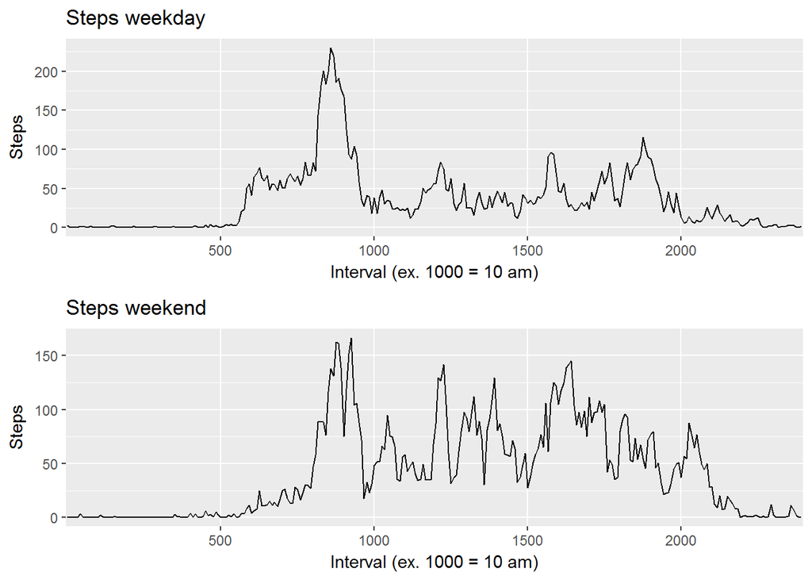

```r
d.clean.steps.by.intervall <- aggregate(steps ~ interval + day.type, d.clean, mean)
d.clean.steps.by.intervall.weekdays <- d.clean.steps.by.intervall %>% filter(day.type == "weekday")
d.clean.steps.by.intervall.weekend <- d.clean.steps.by.intervall %>% filter(day.type == "weekend")
g <- ggplot(d.clean.steps.by.intervall.weekdays, aes(x = interval, y = steps, group = 1))
p3 <- g + geom_line() + labs(x = "Interval (ex. 1000 = 10 am)", y = "Steps", title = "Steps weekday") + scale_x_discrete(breaks = c(500, 1000, 1500, 2000), labels = c("500", "1000", "1500", "2000"))
g <- ggplot(d.clean.steps.by.intervall.weekend, aes(x=interval, y=steps, group = 1))
p4 <- g + geom_line() + labs(x = "Interval (ex. 1000 = 10 am)", y = "Steps", title = "Steps weekend") + scale_x_discrete(breaks = c(500, 1000, 1500, 2000), labels = c("500", "1000", "1500", "2000"))
multiplot(p3, p4, layout = matrix(data = 1:2, nrow = 2, ncol = 1))
```

We can recognize that the person is overall more active at weekends. The peak is for all days at about 9 AM.